# R Notebook: Simulating regreesion with non-norrmal response variables

This example shows that the response variable of a simple linear regression provided that the error terms are normally distributed.

We will show this by simulating a regression model between steps walked versus miles walked. This example is roughly based on my experience as walking.

We will simulate walks between 1 and 5 miles. This will be an experiment. We walk 100 walks because I wish ti have enough points to draw nice looking histograms.

We start by loading the R-packages to carry out our simulation.

```r
library( tidyverse )                    # I live in the tidyverse.
library( cowplot )                      # Extensions to ggplot that I use. use.############################################################################
# Load function definitions
################################################################################

################################################################################
# The following function is use to draw normal quantile-quantile plots.
################################################################################

source('D:/R-Projects/Rsource/plot_qq_norm.R')
```

## Createing the predictor variables

In this section we create the proedictorvariable $miles$. This is the number of miles walks. We will need a value of every walk. There are 5 observation in each replication. Each replication of the experiment has 5 observations. Our replication is defined by

```r
replication <- 1:5                      # Define a single replication of the experiment

replication
```

```
[1] 1 2 3 4 5
```

Wec create twenty replications with a single individual using Stoval Park oval as our test area. Our miles variables for all walks is:

```r
miles <- rep( replication, 20)         # Make twenty copies of the replications.

miles
```

```
  [1] 1 2 3 4 5 1 2 3 4 5 1 2 3 4 5 1 2 3 4 5 1 2 3 4 5 1 2 3 4 5 1 2 3 4 5 1 2 3 4 5 1 2 3 4 5 1
 [47] 2 3 4 5 1 2 3 4 5 1 2 3 4 5 1 2 3 4 5 1 2 3 4 5 1 2 3 4 5 1 2 3 4 5 1 2 3 4 5 1 2 3 4 5 1 2
 [93] 3 4 5 1 2 3 4 5
```

The population model is simple linear regression:

$$Y = \beta_0 + \beta_1 X + e$$

In this model $Y$ is the respinse variabke, $\beta_0$, is the population intercept, $\beta_1$ is the slope of the regression line, and $e$ are the error terms. For this study based on my walks. We use the following values for the population.

$$\beta_0 = 1900$$
$$\beta_1 = 1950$$
The error terms are normally and identicall distributed with a standard deviation of

$$\sigma = 500$$
We can know contruct the relationship between the thoretical regression line. The expected values (thoretical mean for a given predition variable) are given by

$$E[Y|X=x] = \beta_0 + \beta_1 x$$

For example to obtain the mean number of steps per mile we substitue $x = 1$ into the above equation to obtain

```r
mean_steps = 1900 + 1950 * miles

mean_steps
```

```
  [1]  3850  5800  7750  9700 11650  3850  5800  7750  9700 11650  3850  5800  7750  9700 11650
 [16]  3850  5800  7750  9700 11650  3850  5800  7750  9700 11650  3850  5800  7750  9700 11650
 [31]  3850  5800  7750  9700 11650  3850  5800  7750  9700 11650  3850  5800  7750  9700 11650
 [46]  3850  5800  7750  9700 11650  3850  5800  7750  9700 11650  3850  5800  7750  9700 11650
 [61]  3850  5800  7750  9700 11650  3850  5800  7750  9700 11650  3850  5800  7750  9700 11650
 [76]  3850  5800  7750  9700 11650  3850  5800  7750  9700 11650  3850  5800  7750  9700 11650
 [91]  3850  5800  7750  9700 11650  3850  5800  7750  9700 11650
```

Now the observed value also contains the random error. We draw from a normal distribution with a mean of zero and standard deviation of 500.

```r
e <- rnorm( 100,mean = 0, sd = 500 )

e
```

```
  [1]  -319.61939  -266.85277    32.54762  -607.11940   524.54785   561.43392    98.00704
  [8]   336.35080  1112.80993 -1087.17185   399.26779  -430.54559   506.01780 -1272.93520
 [15]  -642.83611   -30.62138   301.61364  -700.09250    60.64628   -39.36378   154.27915
 [22]   662.39762   -41.62809  1175.62840   -38.59054   180.85615  -466.97950    81.59714
 [29]   428.82941   227.84902    15.11218   302.22544  1171.17115   700.82962   133.75704
 [36] -1039.40000   197.64360   381.27519    42.24333  -368.06009  -501.66576  -535.40377
 [43]  -579.80331   506.25431   340.73402   214.78728  -123.18019  -706.48863    31.94382
 [50]  -175.08476   203.67180    43.69651  -160.19746  -870.96655  -165.50923   674.82796
 [57]   448.36092   394.81890   980.56335  -888.69589  -112.91922  -153.65810  -431.77829
 [64]  1074.69820   183.29487  -554.46484  -418.36691   604.71840  -260.25185   806.76208
 [71]   689.15835  -343.84381    61.72225  -244.94928  -288.41608  -319.63274   227.07894
 [78]   463.63651   144.65794   344.99403  -690.80829  -251.93672  -398.90728  -580.12875
 [85]   487.85991   848.10715   471.84548 -1028.05224 -1365.30527  -846.26872   881.57580
 [92]   124.97569    14.33680  -510.31884  -752.69358   -72.86519  -828.99080 -1026.99312
 [99]  -196.63016   453.43504
```

To obtain the observed values of the response variable we add the random error turns to the expected value of the response variable. That is,

$$y = E[Y|x=x] + e$$
we do this ny adding the random error terms to the mean number of steps.

```r
steps <- mean_steps + e                      # Compute observed values.
steps <- round( steps )                 # Round to zero decimal places

steps                                   # Display steps
```

```
  [1]  3530  5533  7783  9093 12175  4411  5898  8086 10813 10563  4249  5369  8256  8427 11007
 [16]  3819  6102  7050  9761 11611  4004  6462  7708 10876 11611  4031  5333  7832 10129 11878
 [31]  3865  6102  8921 10401 11784  2811  5998  8131  9742 11282  3348  5265  7170 10206 11991
 [46]  4065  5677  7044  9732 11475  4054  5844  7590  8829 11484  4525  6248  8145 10681 10761
 [61]  3737  5646  7318 10775 11833  3296  5382  8355  9440 12457  4539  5456  7812  9455 11362
 [76]  3530  6027  8214  9845 11995  3159  5548  7351  9120 12138  4698  6272  6722  8335 10804
 [91]  4732  5925  7764  9190 10897  3777  4971  6723  9503 12103
```

The functions we are using in R expect the data to be either in a data.frame or a tibble. We create a tibble below:

```r
experiment <- tibble( steps, miles )
```

This is our sample data. Let’s plot the distribution of the predictor variable $miles$.

```r
experiment <-
    tibble( steps, miles)

experiment
```

| steps | miles |
| --- | --- |
| 3530 | 1 |
| 5533 | 2 |
| 7783 | 3 |
| 9093 | 4 |
| 12175 | 5 |
| 4411 | 1 |
| 5898 | 2 |
| 8086 | 3 |
| 10813 | 4 |
| 10563 | 5 |

[output cut: 90 more lines]

```r
NA
```

Note that we display a tibble only the first 10 rows are displayed.

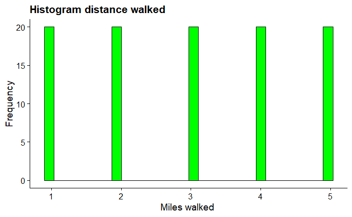

```r
experiment %>%
    ggplot( aes( x = miles )) +
        geom_histogram( color = "black",
                        fill  = "green" ) +
        xlab( "Miles walked ") +
        ylab( "Frequency" ) +
        ggtitle( "Histogram distance walked ") +
        theme_cowplot()
```

```r
NA
```

The distribution of the miles walked is definitely not normally distributed. In fact, it is an uniform distribution.

Now let dway a histogram of the mean values

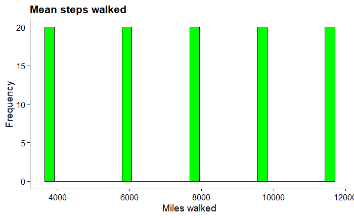

```r
tibble( mean_steps ) %>%
    ggplot( aes( x = mean_steps )) +
        geom_histogram( color = "black",
                        fill  = "green") +
        xlab( "Miles walked") +
        ylab("Frequency" ) +
        ggtitle( "Mean steps walked") +
        theme_cowplot()
```

Note that this is definately not a normal distribution.

Now lets look at the distribution of the error terms.

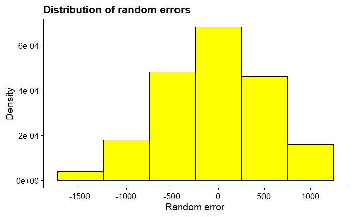

```r
my_bins <-
    round( log2( 100 ))

my_breaks <- pretty( e,
                     bins  = my_bins,
                     min.n = 5,
                     hugh.u.bias = 10 )

my_binwidth <- my_breaks[2] - my_breaks[1]


tibble( e ) %>%
    ggplot( aes( x = e, y = ..density.. )) +
        geom_histogram( binwidth = my_binwidth,
                        color = "black",
                        fill  = "yellow" ) +
    scale_x_continuous( name   = "Random error",
                        breaks = my_breaks,
                        label  = my_breaks ) +
    ylab( "Density" ) +
    ggtitle( "Distribution of random errors") +
    theme_cowplot()
```

Thr distribution is negatively skewed since the lower tail is longer than the upper tail. This may be due to an outlier. It is virtually ompossible to assess the normality of data with the histogram. Therefore we will use a normal quantile-quantile plot.

I have borrowed from the University of Iwoa R-code from there stat department. You can find the tutorial I found thid in [here](http://homepage.stat.uiowa.edu/~luke/classes/STAT4580/qqpp.html). I have changed some of this code to fit by R-prejudices. My altered version can be found on GitHub in my project. The URL of this file is [here](https://github.com/gitHubSlinkman/Rsource/blob/master/plot_qq_norm.R) https://github.com/gitHubSlinkman/Rsource/blob/master/plot_qq_norm.R

[figure not shown]

```r
plot_qq_norm( variable = e,
              variable_name = "Random errors",
              plot_title = "Normal QQ plot of trandom errors" )
```

The nlack dots are the quantiles of tje random errors versus the standard normal distribution quantiles. If the distribution is normal this should be a straight line. Because of sampling error it can be difficult to assess the noermlity as the distributions slivers like a snale. Look at the last point on the right. It look likes the snake is turning to the right. This is a normal distribution because we generated it in R using probability theory. The wiggle is caused by random variation.

The question becomes how can we tell if the line is approximately straight. You will note that the points fall on a set of gay lines. These lines ar generated so that the outer most line is at approximately 95% confidence bounds. We judge a sample to be normally distributed is its values fall in the grey area. We backgound of the graph of there is a kink in the line we judge the data to not be normally distributed.

Now we can generate what would what the values of the the sample would be by adding the error term to the mean value of the response variable.

```r
mean_steps <- beta0 + beta1 * miles
```

[output not shown]

Recall form algebra that this will be a straight line.

Now we added the random error to the values of mean_steps fiving what in the real world be ther observed number of steps. These will be rounded to zero decimal places as we usually don’t talk about fractional steps.

```r
steps <- mean_steps + e
steps <- round( steps )

steps
```

```
  [1]  3530  5533  7783  9093 12175  4411  5898  8086 10813 10563  4249  5369  8256  8427 11007
 [16]  3819  6102  7050  9761 11611  4004  6462  7708 10876 11611  4031  5333  7832 10129 11878
 [31]  3865  6102  8921 10401 11784  2811  5998  8131  9742 11282  3348  5265  7170 10206 11991
 [46]  4065  5677  7044  9732 11475  4054  5844  7590  8829 11484  4525  6248  8145 10681 10761
 [61]  3737  5646  7318 10775 11833  3296  5382  8355  9440 12457  4539  5456  7812  9455 11362
 [76]  3530  6027  8214  9845 11995  3159  5548  7351  9120 12138  4698  6272  6722  8335 10804
 [91]  4732  5925  7764  9190 10897  3777  4971  6723  9503 12103
```

Now we will draw the scatter plot of steps versus miles.

```r
tibble( miles, mean_steps, steps ) %>%
    ggplot( aes( x = miles, y = steps )) +
        geom_point( ) +
    xlab( "Miles walked" ) +
    ylab( "Steps walked ") +
    theme_cowplot()
```

[output not shown]

Lets add the the correct theoretical mean function. We will use the color “black” for this function and make it a line of dashes for the color blind.

```r
tibble( miles, mean_steps, steps ) %>%
    ggplot( aes( x = miles, y = steps )) +
        geom_point( ) +
    geom_abline( intercept = 1900,
                 slope = 1950,
                 color = "black",
                 linetype = 2 ) +
    xlab( "Miles walked" ) +
    ylab( "Steps walked ") +
    theme_cowplot()
```

[output not shown]